# ClusterFittingSouthScania

```python
%matplotlib notebook
```

%matplotlib notebook

```python
%load_ext autoreload
%autoreload 3
```

%load_ext autoreload %autoreload 3

```
The autoreload extension is already loaded. To reload it, use:
  %reload_ext autoreload
```

```python
import sys
import os

IN_COLAB = 'google.colab' in sys.modules

main_dir = '/content/PythonMathematicalModeling/' if IN_COLAB else ''
docs_dir = os.path.join(main_dir, 'docs')
project_dir = os.path.join(docs_dir, 'PlagueProject') if IN_COLAB else ''
data_private_folder = os.path.join(project_dir, 'data', 'private')

# GitHub credentials for Colab

USERNAME="" # Your GitHub username
GH_TOKEN="" # Your github token (Settings -> Developer Settings -> Personal Access Tokens -> Generate new token)

if IN_COLAB:
  ! rm -rf *
  ! git config --system credential.helper store
  ! echo "https://{USERNAME}:{GH_TOKEN}@github.com" > ~/.git-credentials
  ! git clone --recurse-submodules https://github.com/polislizarralde/PythonMathematicalModeling
  sys.path += [main_dir, docs_dir, project_dir, data_private_folder]
```

import sys import os IN_COLAB = 'google.colab' in sys.modules main_dir = '/content/PythonMathematicalModeling/' if IN_COLAB else '' docs_dir = os.path.join(main_dir, 'docs') project_dir = os.path.join(docs_dir, 'PlagueProject') if IN_COLAB else '' data_private_folder = os.path.join(project_dir, 'data', 'private') # GitHub credentials for Colab USERNAME="" # Your GitHub username GH_TOKEN="" # Your github token (Settings -> Developer Settings -> Personal Access Tokens -> Generate new token) if IN_COLAB: ! rm -rf * ! git config --system credential.helper store ! echo "https://{USERNAME}:{GH_TOKEN}@github.com" > ~/.git-credentials ! git clone --recurse-submodules https://github.com/polislizarralde/PythonMathematicalModeling sys.path += [main_dir, docs_dir, project_dir, data_private_folder]

```python
try:
  from funct_process_data import *  # Import all functions from funct_process_data.py
except ImportError:
  if IN_COLAB:
    ! pip3 install -r PythonMathematicalModeling/requirements.txt
    print('Stopping RUNTIME! Please run again.')
    os.kill(os.getpid(), 9)
```

try: from funct_process_data import * # Import all functions from funct_process_data.py except ImportError: if IN_COLAB: ! pip3 install -r PythonMathematicalModeling/requirements.txt print('Stopping RUNTIME! Please run again.') os.kill(os.getpid(), 9)

```python
%matplotlib inline
```

%matplotlib inline

```python
# Get the current working directory
data_folder = "MapScaniaSweden"
SkaneMap_path = os.path.join(data_folder, "Skane1720_1890.shp")

SkaneMap = gpd.read_file(SkaneMap_path)
selected_columns = ['G_NAME', 'GET_END_YE', 'geometry']
SkaneMap = SkaneMap[selected_columns]
```

# Get the current working directory data_folder = "MapScaniaSweden" SkaneMap_path = os.path.join(data_folder, "Skane1720_1890.shp") SkaneMap = gpd.read_file(SkaneMap_path) selected_columns = ['G_NAME', 'GET_END_YE', 'geometry'] SkaneMap = SkaneMap[selected_columns]

```python
# Set the working directory for private files

# Southeast Scania
southeast_path = os.path.join(data_private_folder, 'southeastScania.csv')
southeastScania = pd.read_csv(southeast_path, sep=',')
# Middle Scania
middle_path = os.path.join(data_private_folder, 'middleScania.csv')
middleScania = pd.read_csv(middle_path, sep=',')
# Southwest Scania
southwest_path = os.path.join(data_private_folder, 'southwestScania.csv')
southwestScania = pd.read_csv(southwest_path, sep=',')

# Concatenate all the South Scania data into one dataframe and reset the index
southScania = pd.concat([southeastScania, middleScania, southwestScania], ignore_index=True)
```

# Set the working directory for private files # Southeast Scania southeast_path = os.path.join(data_private_folder, 'southeastScania.csv') southeastScania = pd.read_csv(southeast_path, sep=',') # Middle Scania middle_path = os.path.join(data_private_folder, 'middleScania.csv') middleScania = pd.read_csv(middle_path, sep=',') # Southwest Scania southwest_path = os.path.join(data_private_folder, 'southwestScania.csv') southwestScania = pd.read_csv(southwest_path, sep=',') # Concatenate all the South Scania data into one dataframe and reset the index southScania = pd.concat([southeastScania, middleScania, southwestScania], ignore_index=True)

```python
# Convert WKT (Well-Known Text) geometry to Shapely geometry
southScania['geometry'] = southScania['geometry'].apply(wkt.loads)
# Create a GeoDataFrame from the DataFrame
southScaniaMap = gpd.GeoDataFrame(southScania, geometry='geometry')

# Assigning the coordinate reference system (CRS) to the GeoDataFrame
southScaniaMap = southScaniaMap.set_crs("EPSG:3034")

# For checking the CRS
# southScaniaMap.crs
```

# Convert WKT (Well-Known Text) geometry to Shapely geometry southScania['geometry'] = southScania['geometry'].apply(wkt.loads) # Create a GeoDataFrame from the DataFrame southScaniaMap = gpd.GeoDataFrame(southScania, geometry='geometry') # Assigning the coordinate reference system (CRS) to the GeoDataFrame southScaniaMap = southScaniaMap.set_crs("EPSG:3034") # For checking the CRS # southScaniaMap.crs

We will focus only in the parishes affected by the plague. To do so, first we filter the data frame.

```python
colorByColumn(southScaniaMap, 'EndPlaguePeriod')
plagueSouthScania = southScaniaMap[southScaniaMap['color'] == 'red']
len(plagueSouthScania)
```

colorByColumn(southScaniaMap, 'EndPlaguePeriod') plagueSouthScania = southScaniaMap[southScaniaMap['color'] == 'red'] len(plagueSouthScania)

```
88
```

First, we replaced all the occurences of 'UNDEFINED' and '?' with np.nan in our dataframe. Then, we add new columns to the dataframe where each element is the type pandas._libs.tslibs.timestamps.Timestamp.

```python
plagueSouthScania = plagueSouthScania.replace(['UNDEFINED', '?'], np.nan)
plagueSouthScania['new_format_BeginPlaguePeriod'] = pd.to_datetime(
    plagueSouthScania['BeginPlaguePeriod'], format='%b %Y')
plagueSouthScania['new_format_EndPlaguePeriod'] = pd.to_datetime(
    plagueSouthScania['EndPlaguePeriod'], format='%b %Y')
```

plagueSouthScania = plagueSouthScania.replace(['UNDEFINED', '?'], np.nan) plagueSouthScania['new_format_BeginPlaguePeriod'] = pd.to_datetime( plagueSouthScania['BeginPlaguePeriod'], format='%b %Y') plagueSouthScania['new_format_EndPlaguePeriod'] = pd.to_datetime( plagueSouthScania['EndPlaguePeriod'], format='%b %Y')

Doing the clusters under the condition of shared borders

```python
# Create a graph
G = nx.Graph()

# Add nodes
for index, row in plagueSouthScania.iterrows():
    G.add_node(index, polygon=row['geometry'])

# Add edges
for i, row_i in plagueSouthScania.iterrows():
    for j, row_j in plagueSouthScania.iterrows():
        if i != j and row_i['geometry'].touches(row_j['geometry']):
            G.add_edge(i, j)
# Find connected components
connected_components = list(nx.connected_components(G))

# Create new geodataframes for each subset of connected polygons
gdfs = [gpd.GeoDataFrame(plagueSouthScania.loc[list(component)], crs=plagueSouthScania.crs) for component in connected_components]

plagueSouthScania = plagueSouthScania.copy()

# Initialize a new column in the original dataframe
plagueSouthScania['component'] = -1

# Loop over the list of connected components
for i, component in enumerate(connected_components):
    # For each component, set the 'component' value of the corresponding rows to the current component number
    plagueSouthScania.loc[list(component), 'component'] = i
```

# Create a graph G = nx.Graph() # Add nodes for index, row in plagueSouthScania.iterrows(): G.add_node(index, polygon=row['geometry']) # Add edges for i, row_i in plagueSouthScania.iterrows(): for j, row_j in plagueSouthScania.iterrows(): if i != j and row_i['geometry'].touches(row_j['geometry']): G.add_edge(i, j) # Find connected components connected_components = list(nx.connected_components(G)) # Create new geodataframes for each subset of connected polygons gdfs = [gpd.GeoDataFrame(plagueSouthScania.loc[list(component)], crs=plagueSouthScania.crs) for component in connected_components] plagueSouthScania = plagueSouthScania.copy() # Initialize a new column in the original dataframe plagueSouthScania['component'] = -1 # Loop over the list of connected components for i, component in enumerate(connected_components): # For each component, set the 'component' value of the corresponding rows to the current component number plagueSouthScania.loc[list(component), 'component'] = i

```python
color_list = ['steelblue', 'springgreen', 'aquamarine', 'darkcyan', 'skyblue', 'dodgerblue', 'seagreen', 'coral'
                , 'steelblue', 'springgreen', 'aquamarine', 'darkcyan', 'skyblue', 'dodgerblue', 'seagreen']
fig, ax = plt.subplots(figsize=(7, 4))
SkaneMap.plot(ax=ax, color = 'whitesmoke', edgecolor='black',
              legend=False)
southScaniaMap.plot(ax=ax, color = 'azure',
                        edgecolor='darkgray', legend=False)
for i in range(len(gdfs)):
    cluster_i = plagueSouthScania[plagueSouthScania['component'] == i]
    if len(cluster_i) < 3:
        cluster_i.plot(ax=ax, color = 'peachpuff',
                        edgecolor='black', legend=False)
    elif len(cluster_i) == 4:
        cluster_i.plot(ax=ax, color = 'deepskyblue',
                        edgecolor='black', legend=False)
    elif len(cluster_i) == 9:
        cluster_i.plot(ax=ax, color = 'salmon',
                        edgecolor='black', legend=False)
    elif len(cluster_i) > 9:
        cluster_i.plot(ax=ax, color = 'aquamarine',
                        edgecolor='black', legend=False)
plt.xlabel('Meters')
plt.ylabel('Meters')
plt.show()
```

color_list = ['steelblue', 'springgreen', 'aquamarine', 'darkcyan', 'skyblue', 'dodgerblue', 'seagreen', 'coral' , 'steelblue', 'springgreen', 'aquamarine', 'darkcyan', 'skyblue', 'dodgerblue', 'seagreen'] fig, ax = plt.subplots(figsize=(7, 4)) SkaneMap.plot(ax=ax, color = 'whitesmoke', edgecolor='black', legend=False) southScaniaMap.plot(ax=ax, color = 'azure', edgecolor='darkgray', legend=False) for i in range(len(gdfs)): cluster_i = plagueSouthScania[plagueSouthScania['component'] == i] if len(cluster_i) < 3: cluster_i.plot(ax=ax, color = 'peachpuff', edgecolor='black', legend=False) elif len(cluster_i) == 4: cluster_i.plot(ax=ax, color = 'deepskyblue', edgecolor='black', legend=False) elif len(cluster_i) == 9: cluster_i.plot(ax=ax, color = 'salmon', edgecolor='black', legend=False) elif len(cluster_i) > 9: cluster_i.plot(ax=ax, color = 'aquamarine', edgecolor='black', legend=False) plt.xlabel('Meters') plt.ylabel('Meters') plt.show()

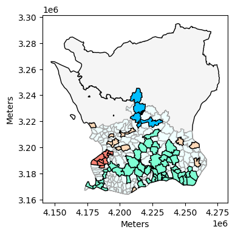

```python
cluster_0 = plagueSouthScania[plagueSouthScania['component'] == 0]
cluster_1 = plagueSouthScania[plagueSouthScania['component'] == 1]
cluster_2 = plagueSouthScania[plagueSouthScania['component'] == 2]
cluster_3 = plagueSouthScania[plagueSouthScania['component'] == 3]
cluster_4 = plagueSouthScania[plagueSouthScania['component'] == 4]
cluster_5 = plagueSouthScania[plagueSouthScania['component'] == 5]
cluster_6 = plagueSouthScania[plagueSouthScania['component'] == 6]
cluster_7 = plagueSouthScania[plagueSouthScania['component'] == 7]
cluster_8 = plagueSouthScania[plagueSouthScania['component'] == 8]
cluster_9 = plagueSouthScania[plagueSouthScania['component'] == 9]
cluster_10 = plagueSouthScania[plagueSouthScania['component'] == 10]
cluster_11 = plagueSouthScania[plagueSouthScania['component'] == 11]
cluster_12 = plagueSouthScania[plagueSouthScania['component'] == 12]
cluster_13 = plagueSouthScania[plagueSouthScania['component'] == 13]
cluster_14 = plagueSouthScania[plagueSouthScania['component'] == 14]
big_cluster = pd.concat([cluster_6,cluster_2,cluster_13], ignore_index=True)
small_cluster = pd.concat([cluster_11, cluster_12], ignore_index=True)
```

cluster_0 = plagueSouthScania[plagueSouthScania['component'] == 0] cluster_1 = plagueSouthScania[plagueSouthScania['component'] == 1] cluster_2 = plagueSouthScania[plagueSouthScania['component'] == 2] cluster_3 = plagueSouthScania[plagueSouthScania['component'] == 3] cluster_4 = plagueSouthScania[plagueSouthScania['component'] == 4] cluster_5 = plagueSouthScania[plagueSouthScania['component'] == 5] cluster_6 = plagueSouthScania[plagueSouthScania['component'] == 6] cluster_7 = plagueSouthScania[plagueSouthScania['component'] == 7] cluster_8 = plagueSouthScania[plagueSouthScania['component'] == 8] cluster_9 = plagueSouthScania[plagueSouthScania['component'] == 9] cluster_10 = plagueSouthScania[plagueSouthScania['component'] == 10] cluster_11 = plagueSouthScania[plagueSouthScania['component'] == 11] cluster_12 = plagueSouthScania[plagueSouthScania['component'] == 12] cluster_13 = plagueSouthScania[plagueSouthScania['component'] == 13] cluster_14 = plagueSouthScania[plagueSouthScania['component'] == 14] big_cluster = pd.concat([cluster_6,cluster_2,cluster_13], ignore_index=True) small_cluster = pd.concat([cluster_11, cluster_12], ignore_index=True)

Initializing the number of patches (n), the population size (patchPop) and the initial conditions for each variable (S0, E0, I0, R0, D0):

```python
class Initial_Model:
    def __init__(self, gdf):
        self.gdf = gdf
        self.n = self.numPatches()
        self.E0 = np.zeros(self.n)
        self.I0 = np.zeros(self.n)
        self.I0[0] = 1.0
        self.R0 = np.zeros(self.n)
        self.D0 = np.zeros(self.n)
        self.S0 = np.zeros(self.n)
        for i in range(self.n):
            self.S0[i] = self.patchPop()[i] - self.E0[i] - \
                self.I0[i] - self.R0[i]

    def patchNames(self, column_name: str = 'ParishName'):
        return self.gdf[column_name].values

    def numPatches(self):
        return len(self.patchNames())

    def patchPop(self, column_pop: str = 'BEF1699'):
        return self.gdf[column_pop].values

    def maxDays(self, column_EndDays: str = 'EndDaysPlague'):
        return self.gdf[column_EndDays].max()
```

class Initial_Model: def __init__(self, gdf): self.gdf = gdf self.n = self.numPatches() self.E0 = np.zeros(self.n) self.I0 = np.zeros(self.n) self.I0[0] = 1.0 self.R0 = np.zeros(self.n) self.D0 = np.zeros(self.n) self.S0 = np.zeros(self.n) for i in range(self.n): self.S0[i] = self.patchPop()[i] - self.E0[i] - \ self.I0[i] - self.R0[i] def patchNames(self, column_name: str = 'ParishName'): return self.gdf[column_name].values def numPatches(self): return len(self.patchNames()) def patchPop(self, column_pop: str = 'BEF1699'): return self.gdf[column_pop].values def maxDays(self, column_EndDays: str = 'EndDaysPlague'): return self.gdf[column_EndDays].max()

Generating the differential equations

```python
SEASONALITY = True
```

SEASONALITY = True

```python
def SEIRD_model(y, t, model_parameters: tuple[dict]):
    global SEASONALITY
    parameters = model_parameters[0]
    gdf = parameters['gdf']
    beta = parameters['beta']
    p = parameters['p']
    gamma = parameters['gamma']
    sigma = parameters['sigma']
    mu = parameters['mu']
    N = parameters['N']
    n = parameters['n']

    # Create a vector of variables
    vars = y
    def entryfun(i, offset): return vars[5 * i + offset]
    # Create an array from the entry function
    entry = np.array([[entryfun(i, j) for j in range(5)] for i in range(len(vars) // 5)])

    beta_matrix =  transmission_matrix_beta(gdf)
    p_matrix = transmission_matrix_p(gdf)

    # For including a seasonal transmission rate
    if SEASONALITY:
        bump_center = parameters['bump_center']
        bump_width = parameters['bump_width']
        bump_height = parameters['bump_height']
        seasonal_rate = lambda w : seasonal_transmission_rate(w, bump_center, bump_width, bump_height)
    else:
        seasonal_rate = lambda w : 0

    matrix = lambda w : (beta + seasonal_rate(w)) * beta_matrix + (p + seasonal_rate(w))  * p_matrix
    sum_transmission = lambda w : np.sum(matrix(w) * entry[:, 2], axis=1)

    dS = -entry[:, 0] / N * sum_transmission(t)
    dE = entry[:, 0] / N * sum_transmission(t) - sigma * entry[:, 1]
    dI = sigma * entry[:, 1] - gamma * entry[:, 2]
    dR = gamma * (1 - mu) * entry[:, 2]
    dD = gamma * mu * entry[:, 2]
    derivatives = np.stack((dS, dE, dI, dR, dD), axis=1).flatten()

    return derivatives

def generate_sol(genInput: dict) -> dict:
    init = genInput['init']
    n = genInput['n']
    initConditions = [val for i in range(n) for val in (
        init['S'][i], init['E'][i], init['I'][i], init['R'][i], init['D'][i])]

    T = genInput['T']
    t = np.linspace(0, T, T+1)

    model = genInput['model']
    output = scipy.odeint(func=model, y0=initConditions, t = t, args=((genInput,),), full_output=1)
    # output is a tuple with two elements, the first element is the solution
    # array and the second element is an object with additional information
    solution = output[0]

    indexVar = {'S': 0, 'E': 1, 'I': 2, 'R': 3, 'D': 4}
    def varSol(patch : int, var : str):
        indice : int = 5*patch + indexVar[var]
        return solution[:, indice]

    return {var: {patch: varSol(patch, var) for patch in range(n)} for var in indexVar.keys()}
```

def SEIRD_model(y, t, model_parameters: tuple[dict]): global SEASONALITY parameters = model_parameters[0] gdf = parameters['gdf'] beta = parameters['beta'] p = parameters['p'] gamma = parameters['gamma'] sigma = parameters['sigma'] mu = parameters['mu'] N = parameters['N'] n = parameters['n'] # Create a vector of variables vars = y def entryfun(i, offset): return vars[5 * i + offset] # Create an array from the entry function entry = np.array([[entryfun(i, j) for j in range(5)] for i in range(len(vars) // 5)]) beta_matrix = transmission_matrix_beta(gdf) p_matrix = transmission_matrix_p(gdf) # For including a seasonal transmission rate if SEASONALITY: bump_center = parameters['bump_center'] bump_width = parameters['bump_width'] bump_height = parameters['bump_height'] seasonal_rate = lambda w : seasonal_transmission_rate(w, bump_center, bump_width, bump_height) else: seasonal_rate = lambda w : 0 matrix = lambda w : (beta + seasonal_rate(w)) * beta_matrix + (p + seasonal_rate(w)) * p_matrix sum_transmission = lambda w : np.sum(matrix(w) * entry[:, 2], axis=1) dS = -entry[:, 0] / N * sum_transmission(t) dE = entry[:, 0] / N * sum_transmission(t) - sigma * entry[:, 1] dI = sigma * entry[:, 1] - gamma * entry[:, 2] dR = gamma * (1 - mu) * entry[:, 2] dD = gamma * mu * entry[:, 2] derivatives = np.stack((dS, dE, dI, dR, dD), axis=1).flatten() return derivatives def generate_sol(genInput: dict) -> dict: init = genInput['init'] n = genInput['n'] initConditions = [val for i in range(n) for val in ( init['S'][i], init['E'][i], init['I'][i], init['R'][i], init['D'][i])] T = genInput['T'] t = np.linspace(0, T, T+1) model = genInput['model'] output = scipy.odeint(func=model, y0=initConditions, t = t, args=((genInput,),), full_output=1) # output is a tuple with two elements, the first element is the solution # array and the second element is an object with additional information solution = output[0] indexVar = {'S': 0, 'E': 1, 'I': 2, 'R': 3, 'D': 4} def varSol(patch : int, var : str): indice : int = 5*patch + indexVar[var] return solution[:, indice] return {var: {patch: varSol(patch, var) for patch in range(n)} for var in indexVar.keys()}

Trying a small dataframe

```python
cluster = big_cluster
cluster = cluster.loc[(cluster['BeginPlaguePeriod']!= 'JAN 1711')
                      & (cluster['BeginPlaguePeriod']!= 'JUN 1711')
                      & (cluster['BeginPlaguePeriod']!= 'OCT 1711')
                      & (cluster['BeginPlaguePeriod']!= 'DEC 1711')
                      & (cluster['BeginPlaguePeriod']!= 'FEB 1715')]
```

cluster = big_cluster cluster = cluster.loc[(cluster['BeginPlaguePeriod']!= 'JAN 1711') & (cluster['BeginPlaguePeriod']!= 'JUN 1711') & (cluster['BeginPlaguePeriod']!= 'OCT 1711') & (cluster['BeginPlaguePeriod']!= 'DEC 1711') & (cluster['BeginPlaguePeriod']!= 'FEB 1715')]

Defining the three connected groups that seem to spread the plague between them.

```python
group1 = cluster[(cluster['ParishName'] == 'GENARP')
                 | (cluster['ParishName'] == 'GRÖNBY')
                 | (cluster['ParishName'] == 'VEBERÖD')
                 | (cluster['ParishName'] == 'VOMB')
                 | (cluster['ParishName'] == 'SLIMMINGE')
                 | (cluster['ParishName'] == 'SKURUP')
                 | (cluster['ParishName'] == 'BÖRRINGE')
                 | (cluster['ParishName'] == 'SVEDALA')
                 | (cluster['ParishName'] == 'SKABERSJÖ')
                 | (cluster['ParishName'] == 'TÖRRINGE')
                 | (cluster['ParishName'] == 'SÖDRA ÅKARP')
                 | (cluster['ParishName'] == 'ARRIE')
]
group1 = group1.reset_index(drop=True)
```

group1 = cluster[(cluster['ParishName'] == 'GENARP') | (cluster['ParishName'] == 'GRÖNBY') | (cluster['ParishName'] == 'VEBERÖD') | (cluster['ParishName'] == 'VOMB') | (cluster['ParishName'] == 'SLIMMINGE') | (cluster['ParishName'] == 'SKURUP') | (cluster['ParishName'] == 'BÖRRINGE') | (cluster['ParishName'] == 'SVEDALA') | (cluster['ParishName'] == 'SKABERSJÖ') | (cluster['ParishName'] == 'TÖRRINGE') | (cluster['ParishName'] == 'SÖDRA ÅKARP') | (cluster['ParishName'] == 'ARRIE') ] group1 = group1.reset_index(drop=True)

```python
group2 = cluster[(cluster['ParishName'] == 'YSTAD')
                 | (cluster['ParishName'] == 'ÖJA')
                 | (cluster['ParishName'] == 'BROMMA')
                 | (cluster['ParishName'] == 'BJÄRESJÖ')
                 | (cluster['ParishName'] == 'STORA KÖPINGE')
                 | (cluster['ParishName'] == 'VALLEBERGA')
                 | ((cluster['ParishName'] == 'HÖRUP') & (cluster['BeginPlaguePeriod']== 'JUL 1712'))
                 | ((cluster['ParishName'] == 'GLEMMINGE') & (cluster['BeginPlaguePeriod']== 'AUG 1712'))
                 | (cluster['ParishName'] == 'INGELSTORP')
                 | (cluster['ParishName'] == 'HAMMENHÖG')
                 | ((cluster['ParishName'] == 'ÖVRABY') & (cluster['BeginPlaguePeriod']== 'SEP 1712'))
                 | (cluster['ParishName'] == 'HEDESKOGA')
                 | ((cluster['ParishName'] == 'ÖVRABY') & (cluster['BeginPlaguePeriod']== 'NOV 1712'))
]
group2 = group2.reset_index(drop=True)
```

group2 = cluster[(cluster['ParishName'] == 'YSTAD') | (cluster['ParishName'] == 'ÖJA') | (cluster['ParishName'] == 'BROMMA') | (cluster['ParishName'] == 'BJÄRESJÖ') | (cluster['ParishName'] == 'STORA KÖPINGE') | (cluster['ParishName'] == 'VALLEBERGA') | ((cluster['ParishName'] == 'HÖRUP') & (cluster['BeginPlaguePeriod']== 'JUL 1712')) | ((cluster['ParishName'] == 'GLEMMINGE') & (cluster['BeginPlaguePeriod']== 'AUG 1712')) | (cluster['ParishName'] == 'INGELSTORP') | (cluster['ParishName'] == 'HAMMENHÖG') | ((cluster['ParishName'] == 'ÖVRABY') & (cluster['BeginPlaguePeriod']== 'SEP 1712')) | (cluster['ParishName'] == 'HEDESKOGA') | ((cluster['ParishName'] == 'ÖVRABY') & (cluster['BeginPlaguePeriod']== 'NOV 1712')) ] group2 = group2.reset_index(drop=True)

```python
group2.at[1, 'BeginPlaguePeriod'] = 'AUG 1712'
group2.at[1, 'EndPlaguePeriod'] = np.NaN
```

group2.at[1, 'BeginPlaguePeriod'] = 'AUG 1712' group2.at[1, 'EndPlaguePeriod'] = np.NaN

```python
group3 = cluster[(cluster['ParishName'] == 'SÖDRA ÅSUM')
                 |(cluster['ParishName'] == 'ÖVED')
                 | (cluster['ParishName'] == 'SÖVDE')
                 | (cluster['ParishName'] == 'BRANDSTAD')
                 | (cluster['ParishName'] == 'BALDRINGE')
                 | (cluster['ParishName'] == 'RAMSÅSA')
                 | (cluster['ParishName'] == 'TRYDE')
                 | (cluster['ParishName'] == 'TRANÅS')
                 | (cluster['ParishName'] == 'LÖVESTAD')
                 | (cluster['ParishName'] == 'VANSTAD')
                 | ((cluster['ParishName'] == 'RÖDDINGE') & (cluster['BeginPlaguePeriod']== 'SEP 1712'))
                 | ((cluster['ParishName'] == 'RÖDDINGE') & (cluster['BeginPlaguePeriod']== 'JUL 1713'))
                 | (cluster['ParishName'] == 'SKÅRBY')
                 | (cluster['ParishName'] == 'SÖVESTAD')
                 | (cluster['ParishName'] == 'VILLIE')
                 | (cluster['ParishName'] == 'BALKÅKRA')
                 | (cluster['ParishName'] == 'SNÅRESTAD')
                 | (cluster['ParishName'] == 'VÄSTRA NÖBBELÖV')
                 | (cluster['ParishName'] == 'ÖSTRA VEMMENHÖG')
                 | (cluster['ParishName'] == 'SVENSTORP')
                 | (cluster['ParishName'] == 'LILLA BEDDINGE')
]
group3 = group3.reset_index(drop=True)
```

group3 = cluster[(cluster['ParishName'] == 'SÖDRA ÅSUM') |(cluster['ParishName'] == 'ÖVED') | (cluster['ParishName'] == 'SÖVDE') | (cluster['ParishName'] == 'BRANDSTAD') | (cluster['ParishName'] == 'BALDRINGE') | (cluster['ParishName'] == 'RAMSÅSA') | (cluster['ParishName'] == 'TRYDE') | (cluster['ParishName'] == 'TRANÅS') | (cluster['ParishName'] == 'LÖVESTAD') | (cluster['ParishName'] == 'VANSTAD') | ((cluster['ParishName'] == 'RÖDDINGE') & (cluster['BeginPlaguePeriod']== 'SEP 1712')) | ((cluster['ParishName'] == 'RÖDDINGE') & (cluster['BeginPlaguePeriod']== 'JUL 1713')) | (cluster['ParishName'] == 'SKÅRBY') | (cluster['ParishName'] == 'SÖVESTAD') | (cluster['ParishName'] == 'VILLIE') | (cluster['ParishName'] == 'BALKÅKRA') | (cluster['ParishName'] == 'SNÅRESTAD') | (cluster['ParishName'] == 'VÄSTRA NÖBBELÖV') | (cluster['ParishName'] == 'ÖSTRA VEMMENHÖG') | (cluster['ParishName'] == 'SVENSTORP') | (cluster['ParishName'] == 'LILLA BEDDINGE') ] group3 = group3.reset_index(drop=True)

```python
cluster_6
```

cluster_6

|  | Region | District(Härad) | ParishName | G_NAME | BEF1699 | BEF1718 | AV_BEF | ChurchBook | OtherSources | BeginPlaguePeriod | EndPlaguePeriod | VictimsNumber | geometry | color | new_format_BeginPlaguePeriod | new_format_EndPlaguePeriod | component |
| --- | --- | --- | --- | --- | --- | --- | --- | --- | --- | --- | --- | --- | --- | --- | --- | --- | --- |
| 107 | SOUTHWEST | BARA | BURLÖV | BURLÖVS | 312 | 352 | 332.0 | 1 | 5 | AUG 1712 | NOV 1712 | 70 | POLYGON ((4190984.276 3193599.608, 4191158.103... | red | 1712-08-01 | 1712-11-01 | 6 |
| 111 | SOUTHWEST | BARA | GÖRSLÖV | GÖRSLÖVS | 87 | 98 | 92.5 | 1 | 5 | NOV 1712 | NOV 1712 | 5 | POLYGON ((4190984.276 3193599.608, 4190788.786... | red | 1712-11-01 | 1712-11-01 | 6 |
| 121 | SOUTHWEST | BARA | TOTTARP | TOTTARPS | 159 | 179 | 169.0 | 1 | 4 | JUL 1712 | SEP 1712 | 40 | POLYGON ((4192980.631 3196551.418, 4193078.773... | red | 1712-07-01 | 1712-09-01 | 6 |
| 140 | SOUTHWEST | OXIE | FOSIE | FOSIE | 226 | 255 | 240.5 | 2 | 4 | AUG 1712 | OCT 1712 | 15 | POLYGON ((4186932.526 3187710.935, 4187078.934... | red | 1712-08-01 | 1712-10-01 | 6 |
| 143 | SOUTHWEST | OXIE | HUSIE | HUSIE | 247 | 279 | 263.0 | 2 | 4 | AUG 1712 | NOV 1712 | 5 | POLYGON ((4188971.830 3191686.652, 4189143.299... | red | 1712-08-01 | 1712-11-01 | 6 |
| 144 | SOUTHWEST | OXIE | LIMHAMN | LIMHAMNS | 226 | 255 | 240.5 | 1 | 5 | JUL 1712 | OCT 1712 | 2 | POLYGON ((4180468.340 3190111.599, 4181258.388... | red | 1712-07-01 | 1712-10-01 | 6 |
| 146 | SOUTHWEST | OXIE | LOCKARP | LOCKARPS | 102 | 115 | 108.5 | 2 | 5 | OCT 1712 | NOV 1712 | 3 | POLYGON ((4188237.472 3186601.883, 4187920.789... | red | 1712-10-01 | 1712-11-01 | 6 |
| 147 | SOUTHWEST | OXIE | MALMÖ SANKT PETRI | MALMÖ SANKT PETRI | 5740 | 1960 | 3850.0 | 1 | 4 | JUN 1712 | JAN 1713 | 335 | POLYGON ((4184045.037 3190353.566, 4183906.760... | red | 1712-06-01 | 1713-01-01 | 6 |
| 159 | SOUTHWEST | OXIE | VÄSTRA SKRÄVLINGE | VÄSTRA SKRÄVLINGE | 220 | 248 | 234.0 | 2 | 4 | JUL 1712 | OCT 1712 | 60 | POLYGON ((4186932.526 3187710.935, 4186323.382... | red | 1712-07-01 | 1712-10-01 | 6 |

```python
# Getting the centroid of each polygon for defining the transmission matrix
group = get_centroid(add_Begin_End_days(sort_by_date(cluster_6), 'new_format_BeginPlaguePeriod', 'new_format_EndPlaguePeriod', 'VictimsNumber'))
model_input = Initial_Model(group)
```

# Getting the centroid of each polygon for defining the transmission matrix group = get_centroid(add_Begin_End_days(sort_by_date(cluster_6), 'new_format_BeginPlaguePeriod', 'new_format_EndPlaguePeriod', 'VictimsNumber')) model_input = Initial_Model(group)

```python
# Model_test = {'model': SEIRD_model,
#               'init': {
#                   'S': model_input.S0,
#                   'E': model_input.E0,
#                   'I': model_input.I0,
#                   'R': model_input.R0,
#                   'D': model_input.D0,
#               },  # defining the initial values for the model
#               'gdf': group,  # defining the dataframe to work with
#               'beta': 0.3,
#               'p': 0.5,
#               'bump_center': 0.1,
#               'bump_width': 180.0,
#               'bump_height': 30.0,
#               'gamma': 0.32,
#               'sigma': 0.2,
#               'mu': 0.4,
#               'N': model_input.patchPop(),
#               'n': model_input.n,
#               'T': model_input.maxDays()}

# model_dict = generate_sol(Model_test)
```

# Model_test = {'model': SEIRD_model, # 'init': { # 'S': model_input.S0, # 'E': model_input.E0, # 'I': model_input.I0, # 'R': model_input.R0, # 'D': model_input.D0, # }, # defining the initial values for the model # 'gdf': group, # defining the dataframe to work with # 'beta': 0.3, # 'p': 0.5, # 'bump_center': 0.1, # 'bump_width': 180.0, # 'bump_height': 30.0, # 'gamma': 0.32, # 'sigma': 0.2, # 'mu': 0.4, # 'N': model_input.patchPop(), # 'n': model_input.n, # 'T': model_input.maxDays()} # model_dict = generate_sol(Model_test)

```python
# %matplotlib inline

# # Set up the data to fit
# beginTime = group['BeginDaysPlague'].values
# endTime = group['EndDaysPlague'].values
# deathData = group['VictimsNumber'].values

# # Number of patches
# n = Model_test['n']

# # Set the figsize for each subplot
# figsize_single_subplot = (8, 2)

# # Calculate the total figure height based on the number of subplots and their height
# fig_height = figsize_single_subplot[1] * n

# # Create a figure and an array of axes with nrows=n and ncols=1
# fig, axes = plt.subplots(nrows=n, ncols=1, figsize=(
#     figsize_single_subplot[0], fig_height), sharex=False)

# # Convert axes to a list if it's not already one
# if n == 1:
#     axes = [axes]

# # Plot model solution D for each patch
# for i in range(n):
#     if deathData[i] != 0 and endTime[i] != 0:
#         # initial_position = beginTime[i]
#         # final_position = endTime[i]
#         # axes[i].plot(initial_position, 0, 'bo')
#         # axes[i].plot(final_position,
#         #              deathData[i], 'bo')
#         axes[i].plot(model_dict['I'][i], color='darkred', label=(model_input.patchNames()[i]))
#         axes[i].set_ylabel('Cumulative Deaths')
#         axes[i].legend(loc='lower right')

#     else:
#         axes[i].plot(model_dict['I'][i],
#                      color='darkred', label=(model_input.patchNames()[i]))
#         axes[i].set_ylabel('Cumulative Deaths')
#         axes[i].legend(loc='upper right')

# # Adjust the layout to avoid overlapping
# plt.tight_layout()
# plt.show()
```

# %matplotlib inline # # Set up the data to fit # beginTime = group['BeginDaysPlague'].values # endTime = group['EndDaysPlague'].values # deathData = group['VictimsNumber'].values # # Number of patches # n = Model_test['n'] # # Set the figsize for each subplot # figsize_single_subplot = (8, 2) # # Calculate the total figure height based on the number of subplots and their height # fig_height = figsize_single_subplot[1] * n # # Create a figure and an array of axes with nrows=n and ncols=1 # fig, axes = plt.subplots(nrows=n, ncols=1, figsize=( # figsize_single_subplot[0], fig_height), sharex=False) # # Convert axes to a list if it's not already one # if n == 1: # axes = [axes] # # Plot model solution D for each patch # for i in range(n): # if deathData[i] != 0 and endTime[i] != 0: # # initial_position = beginTime[i] # # final_position = endTime[i] # # axes[i].plot(initial_position, 0, 'bo') # # axes[i].plot(final_position, # # deathData[i], 'bo') # axes[i].plot(model_dict['I'][i], color='darkred', label=(model_input.patchNames()[i])) # axes[i].set_ylabel('Cumulative Deaths') # axes[i].legend(loc='lower right') # else: # axes[i].plot(model_dict['I'][i], # color='darkred', label=(model_input.patchNames()[i])) # axes[i].set_ylabel('Cumulative Deaths') # axes[i].legend(loc='upper right') # # Adjust the layout to avoid overlapping # plt.tight_layout() # plt.show()

Defining the optimization problem:

```python
# Define the objective function to minimize (sum of squared errors)
def objectiveFunction(parameters, beginTime, endTime, deathData):
    beta, p, bump_center, bump_width, bump_height  = parameters
    model_info = {'model': SEIRD_model,
                  'init': {
                      'S': model_input.S0,
                      'E': model_input.E0,
                      'I': model_input.I0,
                      'R': model_input.R0,
                      'D': model_input.D0,
                  },
                  'gdf': group,
                  # defining the initial values for the model
                  'beta': beta,
                  'p': p,
                  'gamma': 0.06,
                  'sigma': 0.05,
                  'mu': 0.2,
                  'bump_center': bump_center,
                  'bump_width': bump_width,
                  'bump_height': bump_height,
                  'N': model_input.patchPop(),
                  'n': model_input.n,
                  'T': model_input.maxDays()}
    model_sol = generate_sol(model_info)
    totalError = 0
    n = model_info['n']

    # Calculate the error for each patch
    errors = np.zeros(n)
    for i in range(n):
        initial_position = beginTime[i]
        final_position = endTime[i]
        if (deathData[i] != 0 and final_position != 0):
            # errors[i] =  abs(model_sol['D'][i][initial_position] - 1.0) + abs(
            #         model_sol['D'][i][final_position] - deathData[i])
            errors[i] =  ((model_sol['D'][i][initial_position] - 1.0)**2 + (
                    model_sol['D'][i][final_position] - deathData[i])**2)
        # elif (deathData[i] != 0 and final_position == 0):
        #     errors[i] = ((model_sol['D'][i][initial_position] - 1.0)**2) + (
        #         (model_sol['D'][i][initial_position + 30] - deathData[i])**2)
        # elif (deathData[i] == 0 and final_position != 0):
        #     errors[i] = ((model_sol['D'][i][initial_position] - 1.0)**2) + (
        #         (model_sol['D'][i][final_position+1] - 0.0)**2)
        else:
            #errors[i] = abs(model_sol['D'][i][initial_position] - 1.0)
            errors[i] = ((model_sol['D'][i][initial_position] - 1.0)**2)

    # Calculate the total error
    totalError = np.sum(errors)
    return totalError
```

# Define the objective function to minimize (sum of squared errors) def objectiveFunction(parameters, beginTime, endTime, deathData): beta, p, bump_center, bump_width, bump_height = parameters model_info = {'model': SEIRD_model, 'init': { 'S': model_input.S0, 'E': model_input.E0, 'I': model_input.I0, 'R': model_input.R0, 'D': model_input.D0, }, 'gdf': group, # defining the initial values for the model 'beta': beta, 'p': p, 'gamma': 0.06, 'sigma': 0.05, 'mu': 0.2, 'bump_center': bump_center, 'bump_width': bump_width, 'bump_height': bump_height, 'N': model_input.patchPop(), 'n': model_input.n, 'T': model_input.maxDays()} model_sol = generate_sol(model_info) totalError = 0 n = model_info['n'] # Calculate the error for each patch errors = np.zeros(n) for i in range(n): initial_position = beginTime[i] final_position = endTime[i] if (deathData[i] != 0 and final_position != 0): # errors[i] = abs(model_sol['D'][i][initial_position] - 1.0) + abs( # model_sol['D'][i][final_position] - deathData[i]) errors[i] = ((model_sol['D'][i][initial_position] - 1.0)**2 + ( model_sol['D'][i][final_position] - deathData[i])**2) # elif (deathData[i] != 0 and final_position == 0): # errors[i] = ((model_sol['D'][i][initial_position] - 1.0)**2) + ( # (model_sol['D'][i][initial_position + 30] - deathData[i])**2) # elif (deathData[i] == 0 and final_position != 0): # errors[i] = ((model_sol['D'][i][initial_position] - 1.0)**2) + ( # (model_sol['D'][i][final_position+1] - 0.0)**2) else: #errors[i] = abs(model_sol['D'][i][initial_position] - 1.0) errors[i] = ((model_sol['D'][i][initial_position] - 1.0)**2) # Calculate the total error totalError = np.sum(errors) return totalError

Parameter estimation

```python
# Set up the data to fit
beginTime = group['BeginDaysPlague'].values
endTime = group['EndDaysPlague'].values
deathData = group['VictimsNumber'].values


# Choose initial guesses for the parameters to fit
beta_guess = 0.5
p_guess = 0.3
bump_center_guess = 0.1
bump_width_guess = 180.0
bump_height_guess = 30.0


# Minimize the objective function to obtain estimates for beta and gamma
result = optimize.minimize(objectiveFunction, x0=(beta_guess, p_guess, bump_center_guess, bump_width_guess, bump_height_guess ), args=(beginTime, endTime, deathData),
                           method='L-BFGS-B'
                           , bounds=[(0, 1), (0, 1),(0,1),(0, 365), (0, 100)]
                           )

beta_estimated, p_estimated, bump_center_estimated, bump_width_estimated, bump_height_estimated = result.x

print("beta = ", beta_estimated)
print("p = ", p_estimated)
# print("gamma = ", gamma_estimated)
# print("sigma = ", sigma_estimated)
# print("mu = ", mu_estimated)
print("bump_center = ", bump_center_estimated)
print("bump_width = ", bump_width_estimated)
print("bump_height = ", bump_height_estimated)
```

# Set up the data to fit beginTime = group['BeginDaysPlague'].values endTime = group['EndDaysPlague'].values deathData = group['VictimsNumber'].values # Choose initial guesses for the parameters to fit beta_guess = 0.5 p_guess = 0.3 bump_center_guess = 0.1 bump_width_guess = 180.0 bump_height_guess = 30.0 # Minimize the objective function to obtain estimates for beta and gamma result = optimize.minimize(objectiveFunction, x0=(beta_guess, p_guess, bump_center_guess, bump_width_guess, bump_height_guess ), args=(beginTime, endTime, deathData), method='L-BFGS-B' , bounds=[(0, 1), (0, 1),(0,1),(0, 365), (0, 100)] ) beta_estimated, p_estimated, bump_center_estimated, bump_width_estimated, bump_height_estimated = result.x print("beta = ", beta_estimated) print("p = ", p_estimated) # print("gamma = ", gamma_estimated) # print("sigma = ", sigma_estimated) # print("mu = ", mu_estimated) print("bump_center = ", bump_center_estimated) print("bump_width = ", bump_width_estimated) print("bump_height = ", bump_height_estimated)

```
beta =  0.499999980470431
p =  0.2999999882822586
bump_center =  0.1000000351532242
bump_width =  179.99999992269966
bump_height =  30.00000273413966
```

Results from estimations

```python
# Set up the data to fit
beginTime = group['BeginDaysPlague'].values
endTime = group['EndDaysPlague'].values
deathData = group['VictimsNumber'].values

#Estimated parameters for group1 without seasonality and p = 0 or 1 old objective function
# beta_estimated =  0.2791417475872005
# p_estimated =  0.0008691648488012702
# bump_center_estimated =  0.1
# bump_width_estimated =  180.0
# bump_height_estimated =  30.0

# #Estimated parameters for group1 without seasonality and p = 0 or 1 new objective function
# beta_estimated =  0.6203556824484048
# p_estimated =  0.0009204636123439495
# bump_center_estimated =  0.1
# bump_width_estimated =  180.0
# bump_height_estimated =  30.0

#Estimated parameters for group3 without seasonality and with p = 0 or 1
# beta_estimated =  0.1053868589337042
# p_estimated =  0.0055115526615037045
# bump_center_estimated =  0.1
# bump_width_estimated =  180.0
# bump_height_estimated =  30.0

#Estimated parameters for cluster_6 without seasonality and with p = gravity
# beta_estimated =  0.03209853286135653
# p_estimated =  1.0
# bump_center_estimated =  0.1
# bump_width_estimated =  180.0
# bump_height_estimated =  30.0

#Estimated parameters for cluster_6 with seasonality and with p = gravity
beta_estimated =  0.499999980470431
p_estimated =  0.2999999882822586
bump_center_estimated =  0.1000000351532242
bump_width_estimated =  179.99999992269966
bump_height_estimated =  30.00000273413966
#Estimated parameters for cluster_6 without seasonality and with p = 0 or 1
# beta_estimated =  0.06702189095421028
# p_estimated =  0.03050604412998896
# bump_center_estimated =  0.1
# bump_width_estimated =  180.0
# bump_height_estimated =  30.0

#Estimated parameters for group3 without seasonality and with p = 0 or 1

# beta_estimated =  1.8259184082184054e-08
# p_estimated =  0.6558584860995986
# bump_center_estimated =  0.1
# bump_width_estimated =  180.0
# bump_height_estimated =  30.0

#Estimated parameters for group2 without seasonality and p = 0 or 1
# beta_estimated =  1.0
# p_estimated =  0.05031279957398098
# bump_center_estimated =  0.1
# bump_width_estimated =  180.0
# bump_height_estimated =  30.0
```

# Set up the data to fit beginTime = group['BeginDaysPlague'].values endTime = group['EndDaysPlague'].values deathData = group['VictimsNumber'].values #Estimated parameters for group1 without seasonality and p = 0 or 1 old objective function # beta_estimated = 0.2791417475872005 # p_estimated = 0.0008691648488012702 # bump_center_estimated = 0.1 # bump_width_estimated = 180.0 # bump_height_estimated = 30.0 # #Estimated parameters for group1 without seasonality and p = 0 or 1 new objective function # beta_estimated = 0.6203556824484048 # p_estimated = 0.0009204636123439495 # bump_center_estimated = 0.1 # bump_width_estimated = 180.0 # bump_height_estimated = 30.0 #Estimated parameters for group3 without seasonality and with p = 0 or 1 # beta_estimated = 0.1053868589337042 # p_estimated = 0.0055115526615037045 # bump_center_estimated = 0.1 # bump_width_estimated = 180.0 # bump_height_estimated = 30.0 #Estimated parameters for cluster_6 without seasonality and with p = gravity # beta_estimated = 0.03209853286135653 # p_estimated = 1.0 # bump_center_estimated = 0.1 # bump_width_estimated = 180.0 # bump_height_estimated = 30.0 #Estimated parameters for cluster_6 with seasonality and with p = gravity beta_estimated = 0.499999980470431 p_estimated = 0.2999999882822586 bump_center_estimated = 0.1000000351532242 bump_width_estimated = 179.99999992269966 bump_height_estimated = 30.00000273413966 #Estimated parameters for cluster_6 without seasonality and with p = 0 or 1 # beta_estimated = 0.06702189095421028 # p_estimated = 0.03050604412998896 # bump_center_estimated = 0.1 # bump_width_estimated = 180.0 # bump_height_estimated = 30.0 #Estimated parameters for group3 without seasonality and with p = 0 or 1 # beta_estimated = 1.8259184082184054e-08 # p_estimated = 0.6558584860995986 # bump_center_estimated = 0.1 # bump_width_estimated = 180.0 # bump_height_estimated = 30.0 #Estimated parameters for group2 without seasonality and p = 0 or 1 # beta_estimated = 1.0 # p_estimated = 0.05031279957398098 # bump_center_estimated = 0.1 # bump_width_estimated = 180.0 # bump_height_estimated = 30.0

Substituting the estimated values into the model and solving it

```python
model_estimation = {'model': SEIRD_model,
                    'init': {
                        'S': model_input.S0,
                        'E': model_input.E0,
                        'I': model_input.I0,
                        'R': model_input.R0,
                        'D': model_input.D0,
                    },
                    'gdf': group,
                    # defining the initial values for the model
                    'beta': beta_estimated,
                    'p': p_estimated,
                    'bump_center': bump_center_estimated,
                    'bump_width': bump_width_estimated,
                    'bump_height': bump_height_estimated,
                    'gamma': 0.06,
                    'sigma': 0.05,
                    'mu': 0.2,
                    'N': model_input.patchPop(),
                    'n': model_input.n,
                    'T': model_input.maxDays()}
model_solution = generate_sol(model_estimation)
```

model_estimation = {'model': SEIRD_model, 'init': { 'S': model_input.S0, 'E': model_input.E0, 'I': model_input.I0, 'R': model_input.R0, 'D': model_input.D0, }, 'gdf': group, # defining the initial values for the model 'beta': beta_estimated, 'p': p_estimated, 'bump_center': bump_center_estimated, 'bump_width': bump_width_estimated, 'bump_height': bump_height_estimated, 'gamma': 0.06, 'sigma': 0.05, 'mu': 0.2, 'N': model_input.patchPop(), 'n': model_input.n, 'T': model_input.maxDays()} model_solution = generate_sol(model_estimation)

Plotting the cumulative number of deaths to check the model fit

```python
%matplotlib inline

# Number of patches
n = model_estimation['n']

# Set the figsize for each subplot
figsize_single_subplot = (8, 2)

# Calculate the total figure height based on the number of subplots and their height
fig_height = figsize_single_subplot[1] * n

# Create a figure and an array of axes with nrows=n and ncols=1
fig, axes = plt.subplots(nrows=n, ncols=1, figsize=(
    figsize_single_subplot[0], fig_height), sharex=False)

#tick_positions = group['BeginDaysPlague'].values
tick_positions = group['BeginDaysPlague'].values
tick_labels = group['BeginPlaguePeriod'].values
#tick_labels = group['BeginPlaguePeriod'].apply(lambda x: x.strftime('%b %Y') if not pd.isna(x) else None).values

# Dictionary that reduces the plotting to those plots with data
#lookup_index = [1, 2, 4, 8, 9, 12, 16, 17]

# Plot model solution D for each patch
for i in range(n):
    if deathData[i] != 0 and endTime[i] != 0:
        initial_position = beginTime[i]
        final_position = endTime[i]
        axes[i].plot(initial_position, 0, 'bo')
        axes[i].plot(final_position,
                     deathData[i], 'bo')
        axes[i].plot(model_solution['D'][i], color='orange', label=(model_input.patchNames()[i]))
        axes[i].set_ylabel('Cumulative Deaths')
        axes[i].legend(loc = 'lower right')
        axes[i].set_xticks(tick_positions, tick_labels,
                           rotation=70, fontsize=9)
    else:
        axes[i].plot(model_solution['D'][i],
                     color='orange', label=(model_input.patchNames()[i]))
        axes[i].set_ylabel('Cumulative Deaths')
        axes[i].legend(loc='lower right')
        axes[i].set_xticks(tick_positions, tick_labels,
                           rotation=70, fontsize=9)

# Adjust the layout to avoid overlapping
plt.tight_layout()
plt.savefig('cumdeathsgravityseas_cluster_6.png'.format(), dpi=300)
plt.show()
```

%matplotlib inline # Number of patches n = model_estimation['n'] # Set the figsize for each subplot figsize_single_subplot = (8, 2) # Calculate the total figure height based on the number of subplots and their height fig_height = figsize_single_subplot[1] * n # Create a figure and an array of axes with nrows=n and ncols=1 fig, axes = plt.subplots(nrows=n, ncols=1, figsize=( figsize_single_subplot[0], fig_height), sharex=False) #tick_positions = group['BeginDaysPlague'].values tick_positions = group['BeginDaysPlague'].values tick_labels = group['BeginPlaguePeriod'].values #tick_labels = group['BeginPlaguePeriod'].apply(lambda x: x.strftime('%b %Y') if not pd.isna(x) else None).values # Dictionary that reduces the plotting to those plots with data #lookup_index = [1, 2, 4, 8, 9, 12, 16, 17] # Plot model solution D for each patch for i in range(n): if deathData[i] != 0 and endTime[i] != 0: initial_position = beginTime[i] final_position = endTime[i] axes[i].plot(initial_position, 0, 'bo') axes[i].plot(final_position, deathData[i], 'bo') axes[i].plot(model_solution['D'][i], color='orange', label=(model_input.patchNames()[i])) axes[i].set_ylabel('Cumulative Deaths') axes[i].legend(loc = 'lower right') axes[i].set_xticks(tick_positions, tick_labels, rotation=70, fontsize=9) else: axes[i].plot(model_solution['D'][i], color='orange', label=(model_input.patchNames()[i])) axes[i].set_ylabel('Cumulative Deaths') axes[i].legend(loc='lower right') axes[i].set_xticks(tick_positions, tick_labels, rotation=70, fontsize=9) # Adjust the layout to avoid overlapping plt.tight_layout() plt.savefig('cumdeathsgravityseas_cluster_6.png'.format(), dpi=300) plt.show()

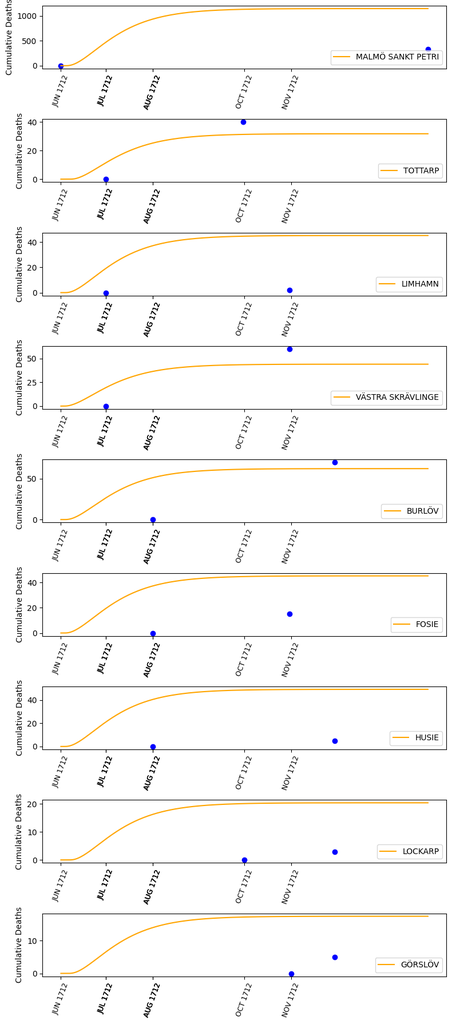

Plotting the daily deaths by parish

```python
# Computing the daily deaths from the model output for a given patch
def daily_deaths(solution_model: dict, patch: int, T_inf: int, T_sup: int) -> list[float]:
    assert T_inf >= 0, "t must be greater than 0"
    assert T_sup >= 0, "t must be greater than 0"
    cumulative_deaths = solution_model['D'][patch]  # list of floats
    return [cumulative_deaths[t+1] - cumulative_deaths[t]
            for t in range(T_inf, T_sup)]
```

# Computing the daily deaths from the model output for a given patch def daily_deaths(solution_model: dict, patch: int, T_inf: int, T_sup: int) -> list[float]: assert T_inf >= 0, "t must be greater than 0" assert T_sup >= 0, "t must be greater than 0" cumulative_deaths = solution_model['D'][patch] # list of floats return [cumulative_deaths[t+1] - cumulative_deaths[t] for t in range(T_inf, T_sup)]

```python
%matplotlib inline

# Number of patches
n = model_estimation['n']


# Set the figsize for each subplot
figsize_single_subplot = (8, 2)

# Calculate the total figure height based on the number of subplots and their height
fig_height = figsize_single_subplot[1] * n

# Create a figure and an array of axes with nrows=n and ncols=1
fig, axes = plt.subplots(nrows=n, ncols=1, figsize=(
    figsize_single_subplot[0], fig_height))

tick_positions = group['BeginDaysPlague'].values
tick_labels = group['BeginPlaguePeriod'].values


for i in range(n):
    # Plot daily deaths for each patch i
    axes[i].plot(daily_deaths(model_solution, i, 0, model_input.maxDays()),
                 color='blue', label=(model_input.patchNames()[i]))
    axes[i].set_ylabel('Daily Deaths')
    axes[i].legend(loc='upper right')
    axes[i].xaxis.set_ticks(tick_positions, tick_labels,
                            rotation=70, fontsize=9)

# Adjust the layout to avoid overlapping
plt.tight_layout()
plt.savefig('dailydeathsgravseas_cluster_6.png'.format(), dpi=300)
plt.show()
```

%matplotlib inline # Number of patches n = model_estimation['n'] # Set the figsize for each subplot figsize_single_subplot = (8, 2) # Calculate the total figure height based on the number of subplots and their height fig_height = figsize_single_subplot[1] * n # Create a figure and an array of axes with nrows=n and ncols=1 fig, axes = plt.subplots(nrows=n, ncols=1, figsize=( figsize_single_subplot[0], fig_height)) tick_positions = group['BeginDaysPlague'].values tick_labels = group['BeginPlaguePeriod'].values for i in range(n): # Plot daily deaths for each patch i axes[i].plot(daily_deaths(model_solution, i, 0, model_input.maxDays()), color='blue', label=(model_input.patchNames()[i])) axes[i].set_ylabel('Daily Deaths') axes[i].legend(loc='upper right') axes[i].xaxis.set_ticks(tick_positions, tick_labels, rotation=70, fontsize=9) # Adjust the layout to avoid overlapping plt.tight_layout() plt.savefig('dailydeathsgravseas_cluster_6.png'.format(), dpi=300) plt.show()

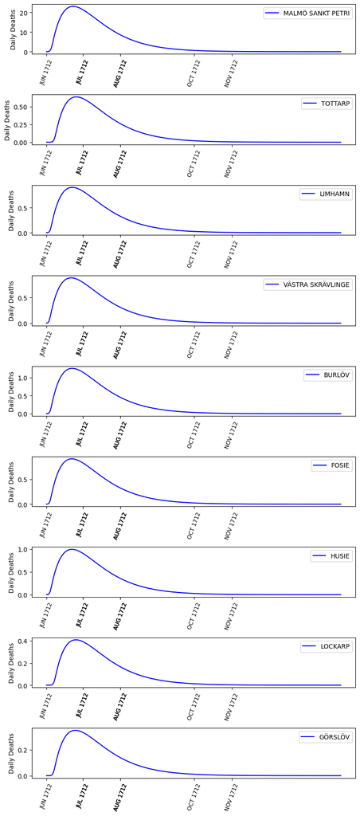

```python
%matplotlib inline

# Number of patches
n = model_estimation['n']


# Set the figsize for each subplot
figsize_single_subplot = (8, 2)

# Calculate the total figure height based on the number of subplots and their height
fig_height = figsize_single_subplot[1] * n

# Create a figure and an array of axes with nrows=n and ncols=1
fig, axes = plt.subplots(nrows=n, ncols=1, figsize=(
    figsize_single_subplot[0], fig_height))

tick_positions = group['BeginDaysPlague'].values
tick_labels = group['BeginPlaguePeriod'].values


for i in range(n):
    # Plot daily deaths for each patch i
    axes[i].plot(model_solution['I'][i],
                 color='red', label=(model_input.patchNames()[i]))
    axes[i].set_ylabel('Infected')
    axes[i].legend(loc='upper right')
    axes[i].xaxis.set_ticks(tick_positions, tick_labels,
                            rotation=70, fontsize=9)

# Adjust the layout to avoid overlapping
plt.tight_layout()
plt.savefig('infectedgravseas_cluster_6.png'.format(), dpi=300)
plt.show()
```

%matplotlib inline # Number of patches n = model_estimation['n'] # Set the figsize for each subplot figsize_single_subplot = (8, 2) # Calculate the total figure height based on the number of subplots and their height fig_height = figsize_single_subplot[1] * n # Create a figure and an array of axes with nrows=n and ncols=1 fig, axes = plt.subplots(nrows=n, ncols=1, figsize=( figsize_single_subplot[0], fig_height)) tick_positions = group['BeginDaysPlague'].values tick_labels = group['BeginPlaguePeriod'].values for i in range(n): # Plot daily deaths for each patch i axes[i].plot(model_solution['I'][i], color='red', label=(model_input.patchNames()[i])) axes[i].set_ylabel('Infected') axes[i].legend(loc='upper right') axes[i].xaxis.set_ticks(tick_positions, tick_labels, rotation=70, fontsize=9) # Adjust the layout to avoid overlapping plt.tight_layout() plt.savefig('infectedgravseas_cluster_6.png'.format(), dpi=300) plt.show()

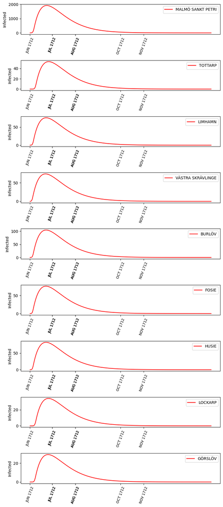